# Investigating Seurat’s AddModuleScore function

Walter Muskovic

23 November, 2019

The source R Markdown document is available here: Download Understanding_AddModuleScore_function.Rmd

From `?AddModuleScore` we get the following information:

Calculate the average expression levels of each program (cluster) on single cell level, subtracted by the aggregated expression of control feature sets. All analyzed features are binned based on averaged expression, and the control features are randomly selected from each bin.

In the source code the authors reference [Tirosh et al, Science, 2016](https://doi.org/10.1126/science.aad0501). From the supplementary materials we get the following:

The top 100 MITF-correlated genes across the entire set of malignant cells were defined as the MITF program, and their average relative expression as the MITF-program cell score. The average expression of the top 100 genes that negatively correlate with the MITF program scores were defined as the AXL program and used to define AXL program cell score. To decrease the effect that the quality and complexity of each cell’s data might have on its MITF/AXL scores we defined control gene-sets and their average relative expression as control scores, for both the MITF and AXL programs. These control cell scores were subtracted from the respective MITF/AXL cell scores. The control gene-sets were defined by first binning all analyzed genes into 25 bins of aggregate expression levels and then, for each gene in the MITF/AXL gene-set, randomly selecting 100 genes from the same expression bin as that gene. In this way, a control gene-sets have a comparable distribution of expression levels to that of the MITF/AXL gene-set and the control gene set is 100-fold larger, such that its average expression is analogous to averaging over 100 randomly-selected gene-sets of the same size as the MITF/AXL gene-set. To calculate significance of the changes in AXL and MITF programs upon relapse, we defined the expression log2-ratio between matched pre- and post- samples for all AXL and MITF program genes (Fig. 3D). Since AXL and MITF programs are inversely related, we flipped the signs of the log-ratios for MITF program genes and used a t-test to examine if the average of the combined set of AXL program and (sign-flipped) MITF program genes is significantly higher than zero, which was the case for four out of six matched sample pairs (Fig. 3D, black arrows).

The code for the function is here:

```r
library(Seurat)
AddModuleScore
```

```
## function (object, features, pool = NULL, nbin = 24, ctrl = 100,
##     k = FALSE, assay = NULL, name = "Cluster", seed = 1, search = FALSE,
##     ...)
## {
##     set.seed(seed = seed)
##     assay.old <- DefaultAssay(object = object)
##     assay <- assay %||% assay.old
##     DefaultAssay(object = object) <- assay
##     assay.data <- GetAssayData(object = object)
##     features.old <- features
##     if (k) {
##         .NotYetUsed(arg = "k")
##         features <- list()
##         for (i in as.numeric(x = names(x = table(object@kmeans.obj[[1]]$cluster)))) {
##             features[[i]] <- names(x = which(x = object@kmeans.obj[[1]]$cluster ==
##                 i))
##         }
##         cluster.length <- length(x = features)
##     }
##     else {
##         if (is.null(x = features)) {
##             stop("Missing input feature list")
##         }
##         features <- lapply(X = features, FUN = function(x) {
##             missing.features <- setdiff(x = x, y = rownames(x = object))
##             if (length(x = missing.features) > 0) {
##                 warning("The following features are not present in the object: ",
##                   paste(missing.features, collapse = ", "), ifelse(test = search,
##                     yes = ", attempting to find updated synonyms",
##                     no = ", not searching for symbol synonyms"),
##                   call. = FALSE, immediate. = TRUE)
##                 if (search) {
##                   tryCatch(expr = {
##                     updated.features <- UpdateSymbolList(symbols = missing.features,
##                       ...)
##                     names(x = updated.features) <- missing.features
##                     for (miss in names(x = updated.features)) {
##                       index <- which(x == miss)
##                       x[index] <- updated.features[miss]
##                     }
```

[output cut: 53 more lines]

```
##         features.use <- features[[i]]
##         data.use <- assay.data[features.use, , drop = FALSE]
##         features.scores[i, ] <- Matrix::colMeans(x = data.use)
##     }
##     features.scores.use <- features.scores - ctrl.scores
##     rownames(x = features.scores.use) <- paste0(name, 1:cluster.length)
##     features.scores.use <- as.data.frame(x = t(x = features.scores.use))
##     rownames(x = features.scores.use) <- colnames(x = object)
##     object[[colnames(x = features.scores.use)]] <- features.scores.use
##     CheckGC()
##     DefaultAssay(object = object) <- assay.old
##     return(object)
## }
## <bytecode: 0x55a757a730a0>
## <environment: namespace:Seurat>
```

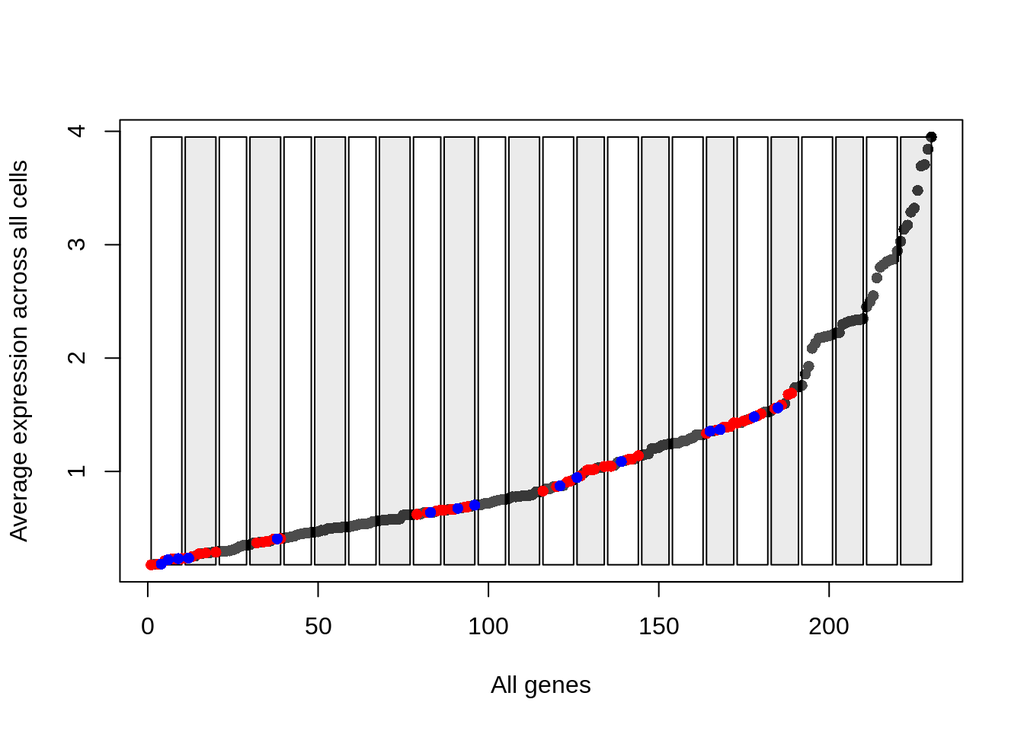

```r
## Load library rlang - need for %||% to work
library(rlang)

## Define two small functions called withing AddModuleScore
# Define small function to check the length of components of a list
LengthCheck <- function(values, cutoff = 0) {
  return(vapply(
    X = values,
    FUN = function(x) {
      return(length(x = x) > cutoff)
    },
    FUN.VALUE = logical(1)
  ))
}
# Call gc() to perform garbage collection
CheckGC <- function() {
  if (getOption(x = "Seurat.memsafe")) {
    gc(verbose = FALSE)
  }
}

## Define variables to input to the AddModuleScore function
object <- pbmc_small
features <- list(c('CD79B','CD79A','CD19','CD180','CD200','CD3D','CD2','CD3E','CD7','CD8A','CD14','CD1C','CD68','CD9','CD247'))
pool <- NULL
nbin <- 24
ctrl <- 5
k <-  FALSE
assay <- NULL
name <- "Cluster"
seed <- 1
search <- FALSE

## Now we can go through the inner workings of the function and inspect what happens at every step
# The first half of the code is checks and balances - small adjustments to the input variables and making sure they are of the expected form
# The second half of the code contains the actual operations performed by the function. I've heavily annotated the code explaining what each step does. I also inlcuded an explanatory plot, depicting how the genes are ranked and binned, and how the control genes are selected from those bins.

#myAddModuleScore <- function (object, features, pool = NULL, nbin = 24, ctrl = 100, k = FALSE, assay = NULL, name = "Cluster", seed = 1, search = FALSE) {
    set.seed(seed = seed)
    assay.old <- DefaultAssay(object = object)
    assay <- assay %||% assay.old
    # If requested, the default assay is switched to the requested assay - it is switched back just before the object is returned at the end of the function
    DefaultAssay(object = object) <- assay
    assay.data <- GetAssayData(object = object)
    features.old <- features

    ### Checks and balances
    if (k) {
        .NotYetUsed(arg = "k")
        features <- list()
        for (i in as.numeric(x = names(x = table(object@kmeans.obj[[1]]$cluster)))) {
            features[[i]] <- names(x = which(x = object@kmeans.obj[[1]]$cluster == i))
            }
        cluster.length <- length(x = features)
    } else {
      if (is.null(x = features)) {
        stop("Missing input feature list")
        }

      # Check all features are present (in the rownames of the object). If some features are missing, print a warning. If search is set to TRUE, try and update.
      # Save the number of gene lists provided in the variable `cluster.length` e.g. if we provided two gene lists; g2m.features and s.features, then cluster.length=2
        features <- lapply(X = features, FUN = function(x) {
            missing.features <- setdiff(x = x, y = rownames(x = object))
            if (length(x = missing.features) > 0) {
                warning("The following features are not present in the object: ",
                  paste(missing.features, collapse = ", "), ifelse(test = search,
                    yes = ", attempting to find updated synonyms",
                    no = ", not searching for symbol synonyms"),
                  call. = FALSE, immediate. = TRUE)
                if (search) {
                  tryCatch(expr = {
                    updated.features <- UpdateSymbolList(symbols = missing.features,
                      ...)
                    names(x = updated.features) <- missing.features
                    for (miss in names(x = updated.features)) {
                      index <- which(x == miss)
                      x[index] <- updated.features[miss]
                    }
                  }, error = function(...) {
                    warning("Could not reach HGNC's gene names database",
                      call. = FALSE, immediate. = TRUE)
                  })
                  missing.features <- setdiff(x = x, y = rownames(x = object))
                  if (length(x = missing.features) > 0) {
                    warning("The following features are still not present in the object: ",
                      paste(missing.features, collapse = ", "),
                      call. = FALSE, immediate. = TRUE)
                  }
                }
            }
            return(intersect(x = x, y = rownames(x = object)))
        })
        cluster.length <- length(x = features)
    }

    # Check that none of the gene lists are empty
    if (!all(LengthCheck(values = features))) {
        warning(paste("Could not find enough features in the object from the following feature lists:",
            paste(names(x = which(x = !LengthCheck(values = features)))),
            "Attempting to match case..."))
        features <- lapply(X = features.old, FUN = CaseMatch,
            match = rownames(x = object))
    }
    # Check to see if difference in case was causing the problem
    if (!all(LengthCheck(values = features))) {
        stop(paste("The following feature lists do not have enough features present in the object:",
            paste(names(x = which(x = !LengthCheck(values = features)))),
            "exiting..."))
    }

    #### End of checks and balances, calculations start here
    # Store all of the gene names from the object
    pool <- pool %||% rownames(x = object)
    # For all genes, get the average expression across all cells
    data.avg <- Matrix::rowMeans(x = assay.data[pool, ])
    # Order genes from lowest average expression to highest average expression
    data.avg <- data.avg[order(data.avg)]
    # Use ggplot2's cut_number function to make n groups with (approximately) equal numbers of observations. I'm not sure what the purpose of 'rnorm(n = length(data.avg))/1e+30' is. I assume we're ading this tiny bit of noise to the data to break ties
    data.cut <- ggplot2::cut_number(x = data.avg + rnorm(n = length(data.avg))/1e+30, n = nbin, labels = FALSE, right = FALSE)
    # Set the names of the cuts as the gene names
    names(x = data.cut) <- names(x = data.avg)
    # Create an empty list the same length as the number of input gene sets. This will contain the NAMES of the control genes
    ctrl.use <- vector(mode = "list", length = cluster.length)

    # For each of the input gene lists:
    for (i in 1:cluster.length) {
      # Get the gene names from the input gene set as a character vector
      features.use <- features[[i]]
      # Loop through 1:num_genes
      # For each gene, find ctrl (default=100) genes from the same expression bin (by looking in data.cut)
      for (j in 1:length(x = features.use)) {
            # 'data.cut[features.use[j]]' gives us the expression bin number
            # We then sample `ctrl` genes from that bin without replacement
            # We add the gene names to ctrl.use
            ctrl.use[[i]] <- c(ctrl.use[[i]],
                               names(x = sample(x = data.cut[which(x = data.cut == data.cut[features.use[j]])],
                                                size = ctrl,
                                                replace = FALSE)))
        }
    }

    # The following explanatory plot should explain what's happened so far
    plot(data.avg, pch=16, ylab="Average expression across all cells", xlab="All genes")
    for(i in unique(data.cut)){
    cut_pos <- which(data.cut==i)
    if(i%%2==0){
      rect(xleft = cut_pos[1], ybottom = min(data.avg), xright = cut_pos[length(cut_pos)], ytop = max(data.avg), col=scales::alpha("grey", 0.3))
    } else {
      rect(xleft = cut_pos[1], ybottom = min(data.avg), xright = cut_pos[length(cut_pos)], ytop = max(data.avg), col=scales::alpha("white", 0.3))
    }
    }
    # Add red points for selected control genes
    points(which(names(data.avg)%in%ctrl.use[[1]]), data.avg[which(names(data.avg)%in%ctrl.use[[1]])], pch=16, col="red")
    # Add blue points for genes in input gene list
    points(which(names(data.avg)%in%features[[1]]), data.avg[which(names(data.avg)%in%features[[1]])], pch=16, col="blue")
```

```r
    # Remove any repeated gene names - even though we set replace=FALSE when we sampled genes from the same expression bin, often there will be more than two genes in our input gene list that fall in the same expression bin, so we can end up sampling the same gene more than once
    ctrl.use <- lapply(X = ctrl.use, FUN = unique)

    ## Get control gene scores
    # Create an empty matrix of dimensions;
      # number of rows equal to number of gene sets
      # number of columns equal to number of cells in input Seurat object
    ctrl.scores <- matrix(data = numeric(length = 1L), nrow = length(x = ctrl.use), ncol = ncol(x = object))
    # Loop through each provided gene set and add to the empty matrix save the mean expression of the control genes in each cell
    for (i in 1:length(ctrl.use)) {
      # Get control gene names as a vector
      features.use <- ctrl.use[[i]]
      # For each cell, calculate the mean expression of all of the control genes
      ctrl.scores[i, ] <- Matrix::colMeans(x = assay.data[features.use,])
    }

    ## Get scores for input gene sets
    # create empty matrix
    features.scores <- matrix(data = numeric(length = 1L), nrow = cluster.length, ncol = ncol(x = object))
    # Loop through input gene sets and calculate the mean expression of these genes for each cell
    for (i in 1:cluster.length) {
        features.use <- features[[i]]
        data.use <- assay.data[features.use, , drop = FALSE]
        features.scores[i, ] <- Matrix::colMeans(x = data.use)
    }

    ## We now have two matrices;
      # ctrl.scores - contains the mean expression of the control genes for each cell
      # features.scores - contains the mean expression of the genes in the input gene set for each cell

    # Subtract the control scores from the feature scores - the idea is that if there is no enrichment of the genes in the geneset in a cell, then the result of this subtraction should be ~ 0
    features.scores.use <- features.scores - ctrl.scores

    # Name the result the "name" variable + whatever the position the geneset was in the input list, e.g. "Cluster1"
    rownames(x = features.scores.use) <- paste0(name, 1:cluster.length)
    # Change the matrix from wide to long
    features.scores.use <- as.data.frame(x = t(x = features.scores.use))
    # Give the rows of the matric, the names of the cells
    rownames(x = features.scores.use) <- colnames(x = object)

    # Add the result as a metadata column to the input Seurat object
    object[[colnames(x = features.scores.use)]] <- features.scores.use
    # Clean up
    CheckGC()
    # Change the default assay back to whatever it was when the object was input
    DefaultAssay(object = object) <- assay.old
    # Return the input Seurat object, now with an additional metadata column containing the module scores for the input gene sets
    #return(object)
#}
```